# Error propagation simulation

## Imports

```python
import itertools
from itertools import combinations, chain

import numpy as np
import pandas as pd
from scipy.stats import norm, t as t_dist
from statsmodels.stats.multitest import multipletests
from joblib import Parallel, delayed
import matplotlib.pyplot as plt
import matplotlib.colors as mcolors
import matplotlib
```

## Overview

For a protein within which p positions are mutated, the biochemical model can be used to predict single mutational effects (SMEs) and epistatic effects (EEs).The biochemical model, a reference-based analysis (RBA), was described in detail by Buda *et al.* (10.1038/s41467-023-44333-5).  
In this model, an SME is defined as the change in function for a single mutation at a given position. An EE corresponds to the deviation between the observed function of a multi-mutational protein variant, and the function predicted by summing all constituent SMEs and lower-order EEs. Since each higher-order EE is computed from an increasing number of lower-order terms, the standard errors of the constituent effects propagate in quadrature, resulting in greater uncertainty at higher interaction orders. This notebook simulates how experimental noise influences the SME/EE prediction accuracy of the biochemical model.

First, we are setting up the global parameters used in this notebook.  
A protein, within which a number of `p` positions undergo mutation, is set up. Here, p = 6.  
The prediction accuracy of the biochemical model is investigated per k-way interaction order and different levels of noise `sigma_range` added to experimental data. For each genotype, `n_reps` experimental replicates are sampled. Here, `n_reps` is set to three, corresponding to data recorded in technical triplicates.  
For each noise level, `mag_value` defines the magnitude value (as $log_{10}$ exponents) of the SMEs/EEs. They were manually chosen and range between ~1.3 and 100 (log-scale).  
The simulation is run for `N_SIM` = 1000 Monte Carlo repetitions. The results are stored per k-way interaction, SME/EE magnitude, and noise level. Six stored metrics (see below) are then used for contour plotting.

- T_%: correctly identified SMEs/EEs (TP_% + TN_%)
- 100-T_%: falsely identified SMEs/EEs
- TP_%: SMEs/EEs predicted correctly, i.e. true positives
- TN_%: absence of SMEs/EEs predicted correctly, i.e. true negatives
- FP_%: SMEs/EEs wrongly predicted, i.e. false positives
- FN_%: absence of SMEs/EEs wrongly predicted, i.e. false negatives

## 0. Global parameters

```python
p = 6          # number of positions
n_reps = 3     # experimental replicates per genotype
N_SIM  = 1000  # Monte-Carlo repetitions

# Magnitude values (log10 exponents)
mag_values = [0.1, 0.2, 0.3, 0.5, 0.7, 1.0, 1.3, 1.5, 1.7, 2.0]

# Added standard deviation
sigma_keys  = ['0_01', '0_02', '0_03', '0_04', '0_05',
               '0_06', '0_07', '0_08', '0_09', '0_1']
sigma_range = np.round(np.arange(0.01, 0.11, 0.01), 2)

METRIC_NAMES = ['T_%', '100-T_%', 'TP_%', 'TN_%', 'FP_%', 'FN_%']
METRIC_IDX   = {name: i for i, name in enumerate(METRIC_NAMES)}
N_METRICS    = len(METRIC_NAMES)

# mut_effects labels for printing and plotting
MUT_EFFECTS_LABELS = {
    1: 'SMEs',
    2: 'Pairwise EEs',
    3: 'Three-way EEs',
    4: 'Four-way EEs',
    5: 'Five-way EEs',
    6: 'Six-way EEs',
}
```

## 1. Build dictionaries for all k-way interaction orders

First, we build a full set of dictionaries for every k-way interaction (SMEs, pairwise EEs, three-way EEs, ..., six-way EEs):

- SMEs are set to `mag_value` for the SMEs simulation, and to 1 for all EEs simulations
- for every k-way interaction of interest, they are set to `mag_value`
- all other interaction types are set to 0

This is done to enable simulating each interaction order in a single code run, without having to manually adjust the ee_overrides dicts.

```python
# Generates the combinatorial position combinations organized by interaction order r (for r=1 to p)
def _keys_by_mut_effects(p: int) -> dict:
    by_mut_effects = {}
    pos_labels = [f'p{i}' for i in range(1, p + 1)]
    for r in range(1, p + 1):
        keys = []
        for combo in itertools.combinations(pos_labels, r):
            keys.append(combo[0] if r == 1 else '|'.join(combo))
        by_mut_effects[r] = keys
    return by_mut_effects

# Returns a nested dictionary, with one entry per interaction order
# dict  {mut_effects_int: ee_overrides_dict}
def build_all_ee_dictionaries(mag_value: float, p: int = 6) -> dict:
    keys_by_mut_effects = _keys_by_mut_effects(p)
    all_dicts = {}

    for target_k in range(1, p + 1):
        d = {}
        for k, keys in keys_by_mut_effects.items():
            for key in keys:
                if k == 1:
                    # SMEs: mag_value for SMEs simulation, 1 otherwise
                    d[key] = mag_value if target_k == 1 else 1
                elif k == target_k:
                    d[key] = mag_value
                else:
                    d[key] = 0
        all_dicts[target_k] = d

    return all_dicts
```

## 2. Helper functions

### 2.1 SME / EE dictionary and table

We then convert the position combinations to binary genotype strings. The string concatenates all amino acids of interest, either in the wild type state (marked by 0) or in the mutated stated (marked by 1).  
The important step here is the generation of a boolean dictionary, where all non-zero SMEs/EEs are set to True. We will use the True/False annotation analogous to the significant/not significant annotation. This dictionary is used to check the prediction accuracy of the biochemical model. For example, a true positive SME/EE corresponds to the case True;True, i.e. the set and predicted SME/EE are significant.

- TN_%: False;False
- FP_%: False;True
- FN_%: True;False,

where the first term corresponds to the set SME/EE and the second to the predicted one.

```python
# Iterates over the same the combinatorial position combinations as _keys_by_mut_effects, but returns a flat dictionary with all keys initialized to 0
def generate_sme_ee_dictionary(p: int) -> dict:
    sme_ee_dict = {}
    pos_labels = [f'p{i}' for i in range(1, p + 1)]
    for r in range(1, p + 1):
        for combo in itertools.combinations(pos_labels, r):
            key = combo[0] if r == 1 else '|'.join(combo)
            sme_ee_dict[key] = 0
    return sme_ee_dict

# Previously built dictionaries containing the SME/EE overrides are applied to the template dictionary (sme_ee_dict)
def set_epistasis(sme_ee_dict: dict, ee_overrides: dict) -> pd.DataFrame:
    sme_ee = sme_ee_dict.copy()
    for pos_combo, effect in ee_overrides.items():
        if pos_combo not in sme_ee:
            raise KeyError(f"Unknown position combination: {pos_combo}")
        sme_ee[pos_combo] = effect
    ee_table = (
        pd.DataFrame(list(sme_ee.items()), columns=['position combination', 'SME/EE'])
        .sort_values('position combination')
        .reset_index(drop=True)
    )
    return ee_table

# Translate position combinations into binary genotype strings
def build_geno_ee_table(ee_table: pd.DataFrame, p: int) -> pd.DataFrame:
    geno_ee = ee_table.copy()
    geno_ee['genotype'] = geno_ee['position combination'].apply(
        lambda comb: ''.join(
            ['1' if f'p{i}' in comb.split('|') else '0' for i in range(1, p + 1)]
        )
    )
    return geno_ee.drop(columns=['position combination'])

# Build {genotype: bool} dictionary where all all non-zero SMEs/EEs are set to True
# Used for downstream biochemical model prediction check
def build_sig_lookup(geno_ee_table: pd.DataFrame) -> dict:
    sig = geno_ee_table.copy()
    sig['sig'] = sig['SME/EE'] != 0
    return dict(zip(sig['genotype'], sig['sig']))
```

### 2.2 Phenotype calculation

For each genotype, every combination of its mutated positions is reconstructed and their SME/EE values are summed to give the phenotype. SMEs/EEs are in log space, meaning that the phenotypes are, too. In line with the set up of the biochemical model, all values are considered to be normalized relative to the wild type background. This is why the wild type's phenotype, appended to the final genotype-phenotype table, is set to zero.

```python
def calculate_phenotypes(geno_ee_table: pd.DataFrame, p: int) -> pd.DataFrame:
    geno_pheno = geno_ee_table.copy()
    ee_dict = dict(zip(geno_pheno['genotype'], geno_pheno['SME/EE']))

    phenotypes = []
    for _, row in geno_pheno.iterrows():
        genotype  = row['genotype']
        positions = [i for i, val in enumerate(genotype) if val == '1']
        total = 0
        for r in range(1, len(positions) + 1):
            for combo in itertools.combinations(positions, r):
                g = ['0'] * len(genotype)
                for pos in combo:
                    g[pos] = '1'
                total += ee_dict.get(''.join(g), 0)
        phenotypes.append(total)

    geno_pheno['phenotype'] = phenotypes
    geno_pheno = geno_pheno.drop(columns=['SME/EE'])
    # Wild type phenotype is set to zero and appended to the dataframe
    geno_pheno.loc[len(geno_pheno)] = {'genotype': '0' * p, 'phenotype': 0}
    return geno_pheno
```

### 2.3 Gaussian error simulation

On the log-scale, the experimental data (and thus the error) is normally distributed.

The previously generated phenotypes are taken as center of Gaussian distributions. Different noise levels are simulated by adding normally distributed noise across a range of standard deviations (sigma). For each genotype, n_reps samples are drawn from the Gaussian distribution centred on its phenotype.

Note that the seed changes between function calls. Within a call, a single rng is created from the seed and used for all draws. The function returns a dictionary keyed by sigma, where each value is a dataframe containing all genotypes and their triplicate measurements for that sigma.

```python
def g_p_map(geno_pheno_table: pd.DataFrame, n_reps: int, seed: int) -> dict:
    rng = np.random.default_rng(seed)
    draws = {}
    for _, row in geno_pheno_table.iterrows():
        for sigma in sigma_range:
            draws[(row['genotype'], float(sigma))] = rng.normal(
                loc=row['phenotype'],
                scale=float(sigma),
                size=n_reps,
            )

    pheno_df = pd.DataFrame()
    for _, row in geno_pheno_table.iterrows():
        for sigma in sigma_range:
            row_data = {'genotype': row['genotype'], 'sigma': sigma}
            rep_draws = draws[(row['genotype'], float(sigma))]
            for rep, value in enumerate(rep_draws, start=1):
                row_data[f'exp{rep}'] = value
            pheno_df = pd.concat([pheno_df, pd.DataFrame([row_data])], ignore_index=True)

    sigma_dfs = {}
    for sigma in sigma_range:
        key = str(sigma).replace('.', '_')
        sigma_dfs[key] = (
            pheno_df[pheno_df['sigma'] == sigma]
            .drop('sigma', axis=1)
            .reset_index(drop=True)
        )
    return sigma_dfs
```

### 2.4 Descriptive statistics

The mean, standard deviation and standard error is computed across replicates.Those stats are added as new columns to each sigma's dataframe, which are then stored in a dictionary with the same sigma-keyed strucure.

```python
def compute_stats(sigma_dfs: dict) -> dict:
    df_stats = {}
    for sigma_key, df in sigma_dfs.items():
        cols = [c for c in df.columns if c.startswith('exp')]
        temp = df.copy()
        temp['mean_value']    = temp[cols].mean(axis=1)
        temp['sd_value']      = temp[cols].std(axis=1)
        temp['total_entries'] = temp[cols].count(axis=1)
        temp['se_value']      = temp['sd_value'] / np.sqrt(temp['total_entries'])
        df_stats[sigma_key]   = temp
    return df_stats
```

### 2.5 Add position indicator columns

For each sigma, p position columns are added to each dataframe and filled with 0 or 1, indicating whether that position is present in the wild type, or the mutated state.

```python
def add_position_columns(df_stats: dict, p: int) -> dict:
    df_pos = {}
    for sigma_key, df in df_stats.items():
        temp = df.copy()
        for i in range(1, p + 1):
            temp[f'p{i}'] = 0
        for index, row in temp.iterrows():
            genotype = row['genotype']
            for position in range(len(genotype)):
                if genotype[position] == '1':
                    temp.at[index, f'p{position + 1}'] = 1
        df_pos[sigma_key] = temp
    return df_pos
```

## 3. Prediction of SMEs/EEs using the biochemical model

We now have everything compute the SMEs/EEs between the six positions of our protein system. The central function implementing this is `alternate_sub_add(x)`. Starting from the highest k-way interactions, it alternately substracts and adds lower-order interactions going backwards, isolating SMEs/EEs.

```python
# Helper functions
def error_prop(x):
    x = np.array(x, dtype=float)
    x = x[~np.isnan(x)]
    return np.nan if len(x) == 0 else np.sqrt(np.sum(x ** 2))


def harm_mean(x):
    x = np.array(x, dtype=float)
    return len(x) / np.sum(1 / x)

# Alternates substraction from right to left
# Initialize counter, sum order effects, start with substracting highest order, then alternate signs for all lower orders
def alternate_sub_add(x):
    x = list(x)
    y = x[-1] # Accesses the last element of list(x), e.g. 7th term = six-way EEs
    counter = True
    if len(x) > 1:
        #range(start, stop, step) -> stop before -1 i.e stop at 0
        for i in range(len(x) - 2, -1, -1):
            if counter:
                y -= x[i]; counter = False
            else:
                y += x[i]; counter = True
    return y # wt (0th order) -> only has one term

# Enumerates every possible subset of positions
def compute_ees(df_pos: dict, p: int) -> dict:
    all_combinations = list(
        chain.from_iterable(combinations(range(1, p + 1), r) for r in range(0, p + 1))
    )
    position_cols = [f'p{i + 1}' for i in range(p)]

    ees_per_sigma = {}
    for sigma_key, df in df_pos.items():
        pos_arr   = df[position_cols].to_numpy(dtype=np.int8)
        muts_arr  = pos_arr.sum(axis=1)
        mean_arr  = df['mean_value'].to_numpy(dtype=float)
        se_arr    = df['se_value'].to_numpy(dtype=float)
        n_arr     = df['total_entries'].to_numpy(dtype=float)
        valid_mask = ~np.isnan(mean_arr) & ~np.isnan(se_arr)

        ees = []
        for combo in all_combinations:
            if len(combo) == 0:
                row_mask = valid_mask
            else:
                combo_idx = np.array(combo, dtype=int) - 1
                # Excludes all rows where any position in combo is mutated
                row_mask = valid_mask & (pos_arr[:, combo_idx] != 1).all(axis=1)

            if not row_mask.any():
                continue

            m_sub   = mean_arr[row_mask]
            se_sub  = se_arr[row_mask]
            n_sub   = n_arr[row_mask]
            mut_sub = muts_arr[row_mask]

            cur_harm_mean = harm_mean(n_sub)
            unique_orders = np.unique(mut_sub)
            vals = np.array([m_sub[mut_sub == o].sum()        for o in unique_orders])
            ses  = np.array([error_prop(se_sub[mut_sub == o]) for o in unique_orders])

            # Apply alternate_sub_add (epistasis approximation)
            alt_sum = alternate_sub_add(vals)
            # Propagation of standard errors in quadrature
            alt_se  = error_prop(ses)

            # Start with all zeros
            ref_geno = ['0'] * p
            # Positions NOT in combo
            current  = sorted(set(range(1, p + 1)) - set(combo))
            for pos in current:
                ref_geno[pos - 1] = 'x'

            # Append results (geno converted back to string)
            ees.append({'new_val': alt_sum, 'new_se': alt_se,
                        'new_n': cur_harm_mean, 'geno': ''.join(ref_geno)})

        # Store sigma-keyed results
        ees_per_sigma[sigma_key] = ees

    return ees_per_sigma
```

## 4. Significance testing of SMEs/EEs

We can now compare the SMEs/EEs predicted by the biochemical model against the ground-truth lookup dictionaries computed earlier.  
For each predicted effect, a t-statistic is computed as the ratio of the estimated SME/EE-value to its propagated SE. An SME/EE is called significant at padj < 0.05. Each prediction boolean is then compared to the ground-truth boolean stored in the lookup dictionary, and labeled as true positive, true negative, false positive, or false negative (see section 2.1). The wild type term is treated as true negative by convention.  
Results are stored as percentages per sigma level.

```python
def compute_T_percent(ees_per_sigma: dict, sig_lookup: dict, sigma_key: str) -> dict:
    test_ees = pd.DataFrame(ees_per_sigma[sigma_key])

    epsilon = 1e-6
    test_ees['t'] = np.where(
        test_ees['new_se'] == 0,
        # Fallback for new_se = 0 to avoid division through zero
        test_ees['new_val'] / (test_ees['new_se'] + epsilon),
        test_ees['new_val'] / test_ees['new_se'],
    )
    # Survival function
    test_ees['p']    = 2 * t_dist.sf(np.abs(test_ees['t']), df=test_ees['new_n'] - 1)
    # Correction of p-values for multiple testing using Benjamini-Hochberg FDR
    test_ees['padj'] = multipletests(test_ees['p'], method='fdr_bh')[1]
    # SME/EE is significant if padj < 0.05
    test_ees['sig']  = test_ees['padj'] < 0.05

    # Check predicted significance against look-up dictionary
    test_ees['geno_binary'] = test_ees['geno'].str.replace('x', '1')
    test_ees['defined_sig'] = test_ees['geno_binary'].map(sig_lookup)

    # Classify SME/EE predictions
    conditions = [
        (test_ees['defined_sig'] == True)  & (test_ees['sig'] == True),
        (test_ees['defined_sig'] == False) & (test_ees['sig'] == False),
        (test_ees['defined_sig'] == False) & (test_ees['sig'] == True),
        (test_ees['defined_sig'] == True)  & (test_ees['sig'] == False),
        # wild type is classified as true negative per convention
        test_ees['defined_sig'].isna(),
    ]
    choices = ['True positive', 'True negative', 'False positive',
               'False negative', 'True negative']
    test_ees['Label'] = np.select(conditions, choices, default='Unknown')

    # Count labels and aggregate them into percentages
    counts = test_ees['Label'].value_counts(normalize=True) * 100
    tp = counts.get('True positive',  0)
    tn = counts.get('True negative',  0)
    fp = counts.get('False positive', 0)
    fn = counts.get('False negative', 0)
    t_pct = tp + tn

    return {
        'T_%': float(t_pct), '100-T_%': float(100 - t_pct),
        'TP_%': float(tp), 'TN_%': float(tn),
        'FP_%': float(fp), 'FN_%': float(fn),
    }
```

## 5. Monte Carlo pipeline function

We define a new function that chains all previously defined functions into the core error propagation simulation pipeline. A single call to this function runs the simulation for one sigma - seed pair. It returns the six metrics defined in `METRIC_NAMES` as a 1D array.

```python
def run_simulation(sigma_key: str, geno_pheno_table: pd.DataFrame,
                   sig_lookup: dict, seed: int = 1) -> np.ndarray:

    # Simulation pipeline that chains all previously defined functions in sequence
    sigma_dfs     = g_p_map(geno_pheno_table, n_reps, seed)
    df_stats      = compute_stats(sigma_dfs)
    df_pos        = add_position_columns(df_stats, p)
    ees_per_sigma = compute_ees(df_pos, p)
    metrics       = compute_T_percent(ees_per_sigma, sig_lookup, sigma_key)

    # Returns 1D array of shape (6,), storing the six metrics defined in METRIC_NAMES
    return np.array([metrics[m] for m in METRIC_NAMES], dtype=float)
```

## 6. Global simulation pipeline function

This function runs the full Monte Carlo pipeline for a given `mag_value` across all k-way interaction orders. For each k-way interaction order, objects that do not depend on sigma or the random seed, e.g. the ee_overrides dicts, the genotype-phenotype table, or the significance lookup dicts, are computed once outside the stochastic loop to avoid redundant calculation.

```python
def run_all_mut_effects(mag_value: float) -> dict:

    # Build all dictionaries upfront -> store SMEs/EEs of different magnitues per k-way interaction
    all_ee_dicts = build_all_ee_dictionaries(mag_value, p)

    # Pre-compute seed-independent objects per mut_effects type
    mut_effects_inputs = {}
    for k in range(1, p + 1):
        ee_overrides     = all_ee_dicts[k]
        sme_ee_dict      = generate_sme_ee_dictionary(p)
        ee_table         = set_epistasis(sme_ee_dict, ee_overrides)
        geno_ee_table    = build_geno_ee_table(ee_table, p)
        sig_lookup       = build_sig_lookup(geno_ee_table)
        geno_pheno_table = calculate_phenotypes(geno_ee_table, p)
        mut_effects_inputs[k] = (geno_pheno_table, sig_lookup)

    n_sigma = len(sigma_keys)
    results_by_mut_effects = {}

    # Monte Carlo pipeline
    for k in range(1, p + 1):
        print(f'  Running {MUT_EFFECTS_LABELS[k]} ...')
        geno_pheno_table, sig_lookup = mut_effects_inputs[k]

        # Run parallel across all available CPU cores
        # lat. "verbosus" - full of words
        results = Parallel(n_jobs=4, verbose=1)(
            delayed(run_simulation)(
                sigma_key=sk,
                geno_pheno_table=geno_pheno_table,
                sig_lookup=sig_lookup,
                seed=l,
            )
            # Loop over all combinations of sigma and simulation replicate
            # 10 x 1,000 = 10,000 independent calls to run_simulation
            for sk in sigma_keys
            for l in range(N_SIM)
        )

        # Results are reshaped into the final matrix
        # np.array(results) stacks the 10,000 result arrays into shape (10,000, 6)
        # .reshape reorganises into sigma x rep loop structure (10, 1,000, 6)
        # .transpose reorders the axes from (n_sigma, N_SIM, 6) to (n_sigma, 6, N_SIM)
        M = np.array(results).reshape(n_sigma, N_SIM, N_METRICS).transpose(0, 2, 1)
        results_by_mut_effects[k] = M

    return results_by_mut_effects
```

## 7. Simulation run and collection of matrices

This is the outermost loop of the entire simulation.

We now combine everything together by calling `run_all_mut_effects`, and return a nested dictionary with the structure {mag_value: {k: M}}:

- The outer key corresponds to the $log_{10}$ SME/EE magnitude
- The inner key k is the interaction order (1-6)
- The inner value M is the result matrix of shape `(n_sigma, 6, N_SIM)`

For example, to access the matrix for mag_value = 1.3 and four-way EEs: `all_matrices[1.3][4]`.

```python
import ctypes

ctypes.windll.kernel32.SetThreadExecutionState(0x80000002)  # prevent sleep

try:

    all_matrices = {}   # {mag_value: {k: M}}

    for mag_value in mag_values:
        print(f'\n── Starting mag_value = {mag_value} ──')
        all_matrices[mag_value] = run_all_mut_effects(mag_value)

    print('\n── All mag_values complete ──')
finally:
    ctypes.windll.kernel32.SetThreadExecutionState(0x80000000)  # re-enable sleep
```

## 8. Contour plots (3×2 grid per metric)

Now, we can use the matrices to visualize each of the saved metrics averaged over all Monte Carlo repetitions. The output are 3x2 contour plot panels, with one panel per k-way interaction order.

### 8.1 Correctly identified SMEs/EEs (T_%)

We start with the mean T_%, the percentage of SMEs/EEs correctly classified as significant (TP_%) or non-significant (TN_%) across 1000 simulation replicates.

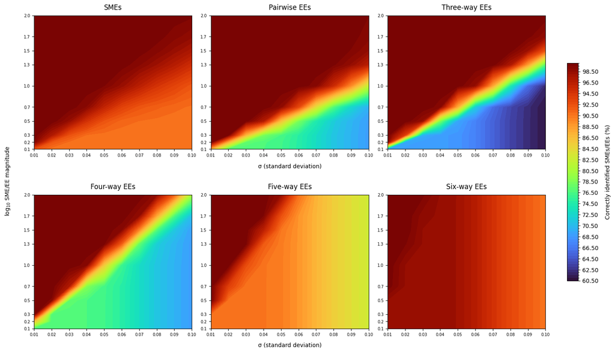

```python
sigma_floats = np.array([float(sk.replace('_', '.')) for sk in sigma_keys])

def make_contour_panel(all_matrices, metric_name, cmap_name='turbo',
                       colorbar_label=None, use_std=False, adaptive_step=False, adaptive_ticks=False):

    m_idx = METRIC_IDX[metric_name]
    stat_fn = np.std if use_std else np.mean


    VMIN_raw, VMAX_raw = np.inf, -np.inf
    for mv, mut_effects_dict in all_matrices.items():
        for k, M in mut_effects_dict.items():
            vals = stat_fn(M[:, m_idx, :], axis=1)
            VMIN_raw = min(VMIN_raw, vals.min())
            VMAX_raw = max(VMAX_raw, vals.max())

    VMIN = np.floor(VMIN_raw * 2) / 2
    VMAX = np.ceil (VMAX_raw * 2) / 2

    if adaptive_step:
        data_range = VMAX - VMIN
        STEP_raw = data_range / 12
        magnitude = 10 ** np.floor(np.log10(STEP_raw))
        normalized = STEP_raw / magnitude
        if normalized < 1.5:
            STEP = 1.0 * magnitude
        elif normalized < 3.5:
            STEP = 2.0 * magnitude
        elif normalized < 7.5:
            STEP = 5.0 * magnitude
        else:
            STEP = 10.0 * magnitude
    else:
        STEP = 0.5

    LEVELS   = np.arange(VMIN, VMAX + STEP, STEP)

    N_COLORS = max(len(LEVELS) - 1, 1)
    try:
        BASE_CMAP = matplotlib.colormaps.get_cmap(cmap_name)
    except (AttributeError, KeyError):
        BASE_CMAP = plt.cm.get_cmap(cmap_name)
    CMAP = mcolors.ListedColormap(BASE_CMAP(np.linspace(0, 1, N_COLORS)))
    norm = mcolors.BoundaryNorm(LEVELS, N_COLORS)

    fig, axes = plt.subplots(2, 3, figsize=(16, 9), sharey='row')
    fig.subplots_adjust(left=0.05, right=0.88, bottom=0.1, top=0.95,
                        wspace=0.12, hspace=0.34)
    cf_last = None

    for k in range(1, 7):
        idx = k - 1
        row, col = divmod(idx, 3)
        ax = axes[row][col]

        mag_arr_list, means_list = [], []
        for mv in sorted(all_matrices.keys()):
            M = all_matrices[mv][k]
            mag_arr_list.append(mv)
            means_list.append(stat_fn(M[:, m_idx, :], axis=1))

        mag_arr = np.array(mag_arr_list)
        Z       = np.array(means_list)
        X, Y    = np.meshgrid(sigma_floats, mag_arr)

        cf = ax.contourf(X, Y, Z, levels=LEVELS, cmap=CMAP, norm=norm, extend='neither')
        cf_last = cf

        ax.set_xticks(sigma_floats)
        ax.set_yticks(mag_arr)
        ax.tick_params(axis='both', labelsize=7)
        ax.set_title(MUT_EFFECTS_LABELS[k], loc='center', fontsize=12,
                     fontweight='normal', pad=10)

    for ax_row in axes:
        for ax in ax_row:
            ax.tick_params(axis='y', labelleft=True)


    cb = fig.colorbar(cf_last, ax=axes, fraction=0.02, pad=0.04, extend='neither')
    if colorbar_label:
        cb.set_label(colorbar_label, fontsize=10, labelpad=12)
    if adaptive_ticks:
        cb.set_ticks(LEVELS)
        cb.set_ticklabels([f'{l:.2f}' for l in LEVELS])
    else:
        cb.set_ticks([t for t in np.arange(VMIN, VMAX + 1, 2) if t <= VMAX])
        cb.formatter = matplotlib.ticker.FormatStrFormatter('%.2f')
        cb.update_ticks()

    # After the plotting loop, read actual axes positions
    fig.canvas.draw()
    ax_left  = axes[0, 0].get_position().x0
    ax_right = axes[0, 2].get_position().x1
    ax_mid   = (ax_left + ax_right) / 2

    # Center x-axis label on the length of the three plots
    fig.text(0.01, 0.5, 'log$_{10}$ SME/EE magnitude',
             va='center', ha='center', rotation='vertical', fontsize=10)
    fig.text(ax_mid, 0.54, 'σ (standard deviation)', va='center', ha='center', fontsize=10) #top row
    fig.text(ax_mid, 0.055, 'σ (standard deviation)', va='center', ha='center', fontsize=10) #bottom row

    plt.show()


# T_%  mean
make_contour_panel(
    all_matrices,
    metric_name='T_%',
    cmap_name='turbo',
    colorbar_label='Correctly identified SMEs/EEs (%)',
)
```

### 8.2 Standard deviation of T_%

Then the standard deviation of T_% across simulation replicates.

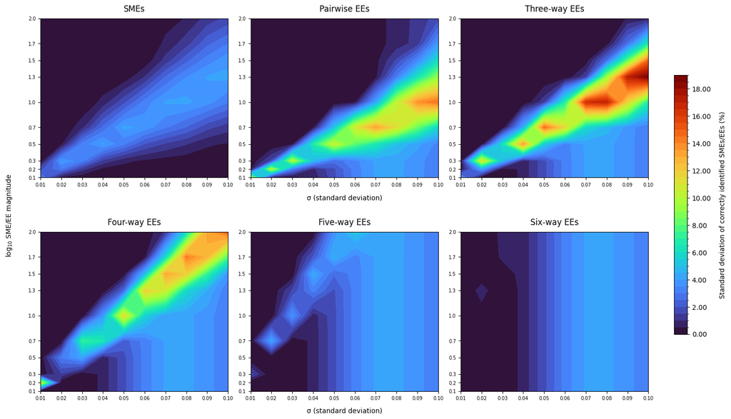

```python
make_contour_panel(
    all_matrices,
    metric_name='T_%',
    cmap_name='turbo',
    colorbar_label='Standard deviation of correctly identified SMEs/EEs (%)',
    use_std=True,
    adaptive_step=False,
    adaptive_ticks=False
)
```

### 8.3 Epistatic effects identified as falsely positive (FP_%)

Next, the mean false positive rate (FP_%), i.e., cases where the biochemical model predicted a SME/EE as significant, but the ground-truth lookup dictionary defined it as non-significant.

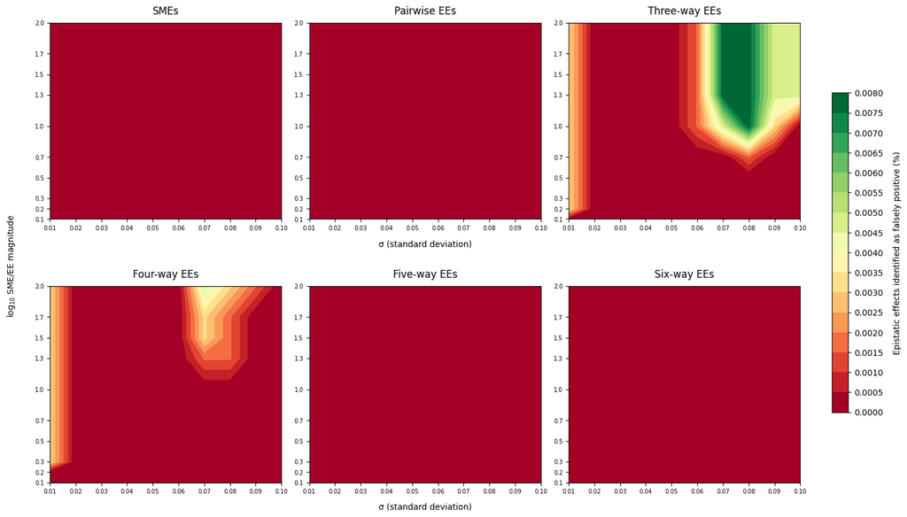

```python
m_idx = METRIC_IDX['FP_%']

VMIN = 0.0
VMAX = 0.008

STEP = 0.0005
LEVELS = np.arange(VMIN, VMAX + STEP, STEP)
N_COLORS = max(len(LEVELS) - 1, 1)

try:
    BASE_CMAP = matplotlib.colormaps.get_cmap('RdYlGn')
except (AttributeError, KeyError):
    BASE_CMAP = plt.cm.get_cmap('RdYlGn')
CMAP = mcolors.ListedColormap(BASE_CMAP(np.linspace(0, 1, N_COLORS)))
norm = mcolors.BoundaryNorm(LEVELS, N_COLORS)

fig, axes = plt.subplots(2, 3, figsize=(16, 9), sharey='row')
fig.subplots_adjust(left=0.05, right=0.88, bottom=0.1, top=0.95,
                    wspace=0.12, hspace=0.34)
cf_last = None

for k in range(1, 7):
    idx = k - 1
    row, col = divmod(idx, 3)
    ax = axes[row][col]

    mag_arr_list, means_list = [], []
    for mv in sorted(all_matrices.keys()):
        M = all_matrices[mv][k]
        mag_arr_list.append(mv)
        means_list.append(np.mean(M[:, m_idx, :], axis=1))

    mag_arr = np.array(mag_arr_list)
    Z       = np.array(means_list)
    X, Y    = np.meshgrid(sigma_floats, mag_arr)

    cf = ax.contourf(X, Y, Z, levels=LEVELS, cmap=CMAP, norm=norm, extend='neither')
    cf_last = cf

    ax.set_xticks(sigma_floats)
    ax.set_yticks(mag_arr)
    ax.tick_params(axis='both', labelsize=7)
    ax.set_title(MUT_EFFECTS_LABELS[k], fontsize=12, fontweight='normal', pad=10)

for ax_row in axes:
    for ax in ax_row:
        ax.tick_params(axis='y', labelleft=True)

cb = fig.colorbar(cf_last, ax=axes, fraction=0.02, pad=0.04, extend='max')
cb.set_label('Epistatic effects identified as falsely positive (%)', fontsize=10, labelpad=12)
cb.set_ticks(np.arange(VMIN, VMAX + STEP, STEP))
cb.set_ticklabels([f'{t:.4f}' for t in np.arange(VMIN, VMAX + STEP, STEP)])

fig.canvas.draw()
ax_left  = axes[0, 0].get_position().x0
ax_right = axes[0, 2].get_position().x1
ax_mid   = (ax_left + ax_right) / 2
fig.text(0.01, 0.5, 'log$_{10}$ SME/EE magnitude',
         va='center', ha='center', rotation='vertical', fontsize=10)
fig.text(ax_mid, 0.54, 'σ (standard deviation)', va='center', ha='center', fontsize=10)
fig.text(ax_mid, 0.055, 'σ (standard deviation)', va='center', ha='center', fontsize=10)

plt.show()
```

### 8.4 Epistatic effects identified as falsely negative (FN_%)

Finally, the mean false negative rate (FN_%), i.e. a SME/EE predicted as non-significant, but the ground-truth lookup dictionary defined it as significant.

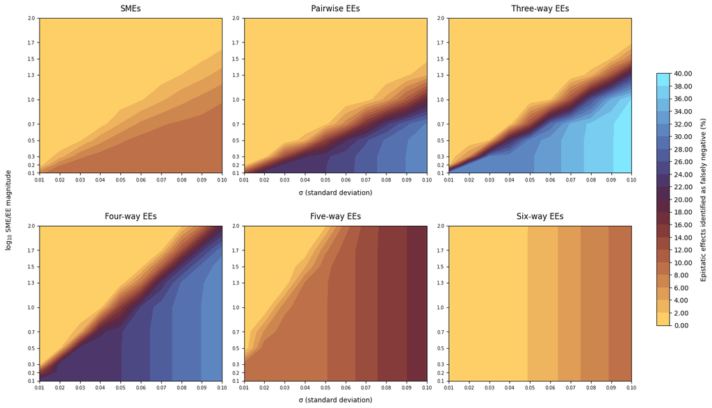

```python
make_contour_panel(
    all_matrices,
    metric_name='FN_%',
    cmap_name='managua',
    adaptive_step=True,
    adaptive_ticks=True,
    colorbar_label='Epistatic effects identified as falsely negative (%)',
)
```

## 9. Summary CSV

The final .csv-file outputs the compiled means from the 1000 simulations for T_%, stdev T_%, FP_%, stdev FP_%, FN_%, and stdev_FN% across all (mut_effects, mag_value, sigma) combinations.

```python
# Returns tidy dataframe
def build_summary_csv(all_matrices: dict) -> pd.DataFrame:

    rows = []
    target_metrics = {
        'T_%':  ('T_%',  False),
        'stdev T_%':  ('T_%',  True),
        'FP_%':  ('FP_%', False),
        'stdev FP_%': ('FP_%', True),
        'FN_%':  ('FN_%', False),
        'stdev FN_%': ('FN_%', True),
    }

    for mag_value in sorted(all_matrices.keys()):
        for k in range(1, 7):
            M = all_matrices[mag_value][k]  # shape (n_sigma, 6, N_SIM)
            for si, sk in enumerate(sigma_keys):
                sigma_val = float(sk.replace('_', '.'))
                row = {
                    'mut_effects': MUT_EFFECTS_LABELS[k],
                    'mag_value':   mag_value,
                    'sigma':       sigma_val,
                }
                for col_name, (metric, use_std) in target_metrics.items():
                    m_idx = METRIC_IDX[metric]
                    fn = np.std if use_std else np.mean
                    val = fn(M[si, m_idx, :])
                    row[col_name] = val
                rows.append(row)

    df = pd.DataFrame(rows)
    col_order = ['mut_effects', 'mag_value', 'sigma',
                 'T_%', 'stdev T_%', 'FP_%', 'stdev FP_%', 'FN_%', 'stdev FN_%']
    return df[col_order]


summary_df = build_summary_csv(all_matrices)
print(summary_df.head().to_string(index=False))
```

```
mut_effects  mag_value  sigma       T_%  stdev T_%  FP_%  stdev FP_%     FN_%  stdev FN_%
       SMEs        0.1   0.01 92.490625   3.186260   0.0         0.0 7.509375    3.186260
       SMEs        0.1   0.02 90.667187   0.370649   0.0         0.0 9.332812    0.370649
       SMEs        0.1   0.03 90.629688   0.110386   0.0         0.0 9.370313    0.110386
       SMEs        0.1   0.04 90.626563   0.049386   0.0         0.0 9.373437    0.049386
       SMEs        0.1   0.05 90.625000   0.000000   0.0         0.0 9.375000    0.000000
```